# Bank_Personal_Loan_Modelling

```python
#Import required libraries

import numpy as np
import pandas as pd
import matplotlib.pyplot as plt
import sklearn
import seaborn as sns

%matplotlib inline
from scipy.stats import zscore, norm

# Modelling - LR, KNN, NB, Metrics
from sklearn import metrics
from sklearn.metrics import classification_report, confusion_matrix, roc_auc_score, roc_curve, accuracy_score
from sklearn.model_selection import train_test_split, GridSearchCV, StratifiedKFold
from sklearn.linear_model import LogisticRegression
from sklearn.neighbors import KNeighborsClassifier
from sklearn.tree import DecisionTreeClassifier
from sklearn.naive_bayes import GaussianNB

from os import system

# Suppress warnings
import warnings; warnings.filterwarnings('ignore')
pd.options.display.max_rows = 4000
```

```python
# Load the dataset and read the data
data = pd.read_csv('Bank_Personal_Loan_Modelling.csv')
data.head()
```

|  | ID | Age | Experience | Income | ZIP Code | Family | CCAvg | Education | Mortgage | Personal Loan | Securities Account | CD Account | Online | CreditCard |
| --- | --- | --- | --- | --- | --- | --- | --- | --- | --- | --- | --- | --- | --- | --- |
| 0 | 1 | 25 | 1 | 49 | 91107 | 4 | 1.6 | 1 | 0 | 0 | 1 | 0 | 0 | 0 |
| 1 | 2 | 45 | 19 | 34 | 90089 | 3 | 1.5 | 1 | 0 | 0 | 1 | 0 | 0 | 0 |
| 2 | 3 | 39 | 15 | 11 | 94720 | 1 | 1.0 | 1 | 0 | 0 | 0 | 0 | 0 | 0 |
| 3 | 4 | 35 | 9 | 100 | 94112 | 1 | 2.7 | 2 | 0 | 0 | 0 | 0 | 0 | 0 |
| 4 | 5 | 35 | 8 | 45 | 91330 | 4 | 1.0 | 2 | 0 | 0 | 0 | 0 | 0 | 1 |

```python
Attribute Information:

ID: Customer ID
Age: Customers age in completed years
Experience : no.of years of professional experience
Income: Annual income of the customer (thousand dollars)
ZIP Code: Home Address ZIP code.
Family: Family size of the customer
CCAvg: Avg. spending on credit cards per month (thousand dollars)
Education: Education Level. 1: Undergrad; 2: Graduate; 3: Advanced/Professional
Mortgage: Value of house mortgage if any. (thousand dollars)
Personal Loan: Did this customer accept the personal loan offered in the last campaign?
Securities Account: Does the customer have a securities account with the bank?
CD Account: Does the customer have a certificate of deposit (CD) account with the bank?
Online: Does the customer use internet banking facilities?
Credit card: Does the customer use a credit card issued by bank
```

# Data Description & Distribution:

```python
# dataset dimensions
data.shape
```

```
(5000, 14)
```

```python
# inforamtaion about the data attributes
data.info()
```

```
<class 'pandas.core.frame.DataFrame'>
RangeIndex: 5000 entries, 0 to 4999
Data columns (total 14 columns):
ID                    5000 non-null int64
Age                   5000 non-null int64
Experience            5000 non-null int64
Income                5000 non-null int64
ZIP Code              5000 non-null int64
Family                5000 non-null int64
CCAvg                 5000 non-null float64
Education             5000 non-null int64
Mortgage              5000 non-null int64
Personal Loan         5000 non-null int64
Securities Account    5000 non-null int64
CD Account            5000 non-null int64
Online                5000 non-null int64
CreditCard            5000 non-null int64
dtypes: float64(1), int64(13)
memory usage: 547.0 KB
```

```python
# Checking for null values
data.isnull().sum()
```

```
ID                    0
Age                   0
Experience            0
Income                0
ZIP Code              0
Family                0
CCAvg                 0
Education             0
Mortgage              0
Personal Loan         0
Securities Account    0
CD Account            0
Online                0
CreditCard            0
dtype: int64
```

```python
#checking for duplicates
data.duplicated().any()
```

```
False
```

```python
#Descriptive statistics for numeric attributes
data.describe().T
```

|  | count | mean | std | min | 25% | 50% | 75% | max |
| --- | --- | --- | --- | --- | --- | --- | --- | --- |
| ID | 5000.0 | 2500.500000 | 1443.520003 | 1.0 | 1250.75 | 2500.5 | 3750.25 | 5000.0 |
| Age | 5000.0 | 45.338400 | 11.463166 | 23.0 | 35.00 | 45.0 | 55.00 | 67.0 |
| Experience | 5000.0 | 20.104600 | 11.467954 | -3.0 | 10.00 | 20.0 | 30.00 | 43.0 |
| Income | 5000.0 | 73.774200 | 46.033729 | 8.0 | 39.00 | 64.0 | 98.00 | 224.0 |
| ZIP Code | 5000.0 | 93152.503000 | 2121.852197 | 9307.0 | 91911.00 | 93437.0 | 94608.00 | 96651.0 |
| Family | 5000.0 | 2.396400 | 1.147663 | 1.0 | 1.00 | 2.0 | 3.00 | 4.0 |
| CCAvg | 5000.0 | 1.937938 | 1.747659 | 0.0 | 0.70 | 1.5 | 2.50 | 10.0 |
| Education | 5000.0 | 1.881000 | 0.839869 | 1.0 | 1.00 | 2.0 | 3.00 | 3.0 |
| Mortgage | 5000.0 | 56.498800 | 101.713802 | 0.0 | 0.00 | 0.0 | 101.00 | 635.0 |
| Personal Loan | 5000.0 | 0.096000 | 0.294621 | 0.0 | 0.00 | 0.0 | 0.00 | 1.0 |
| Securities Account | 5000.0 | 0.104400 | 0.305809 | 0.0 | 0.00 | 0.0 | 0.00 | 1.0 |
| CD Account | 5000.0 | 0.060400 | 0.238250 | 0.0 | 0.00 | 0.0 | 0.00 | 1.0 |
| Online | 5000.0 | 0.596800 | 0.490589 | 0.0 | 0.00 | 1.0 | 1.00 | 1.0 |
| CreditCard | 5000.0 | 0.294000 | 0.455637 | 0.0 | 0.00 | 0.0 | 1.00 | 1.0 |

Observation: "Experience" column has negative values, that needs to be addressed ID and Zipcode can be dropped, as they are irrelevant to the analysis

```python
# total number of rows with a -ve experience value
data[data.Experience < 0].Experience.count()
```

```
52
```

# Data Preparation

Deal with Negative Values

```python
#cleaning the -ve values by replacing them with the median
positiveExp = data.loc[data['Experience'] >0]
negExp = data.loc[data['Experience'] <0]
column_name = 'Experience'
mylist = negExp['ID'].tolist() # getting the customer ID who has negative experience
for id in mylist:
    age = data.loc[np.where(data['ID']==id)]["Age"].tolist()[0]
    education = data.loc[np.where(data['ID']==id)]["Education"].tolist()[0]
    df_selected = positiveExp[(positiveExp.Age == age) & (positiveExp.Education == education)]
    exp = df_selected['Experience'].median()
    data.loc[data.loc[np.where(data['ID']==id)].index, 'Experience'] = exp
```

```python
#check if any more negative values exist
newNeg = data.Experience < 0
newNeg.value_counts()
```

```
False    5000
Name: Experience, dtype: int64
```

# Data Visualization:

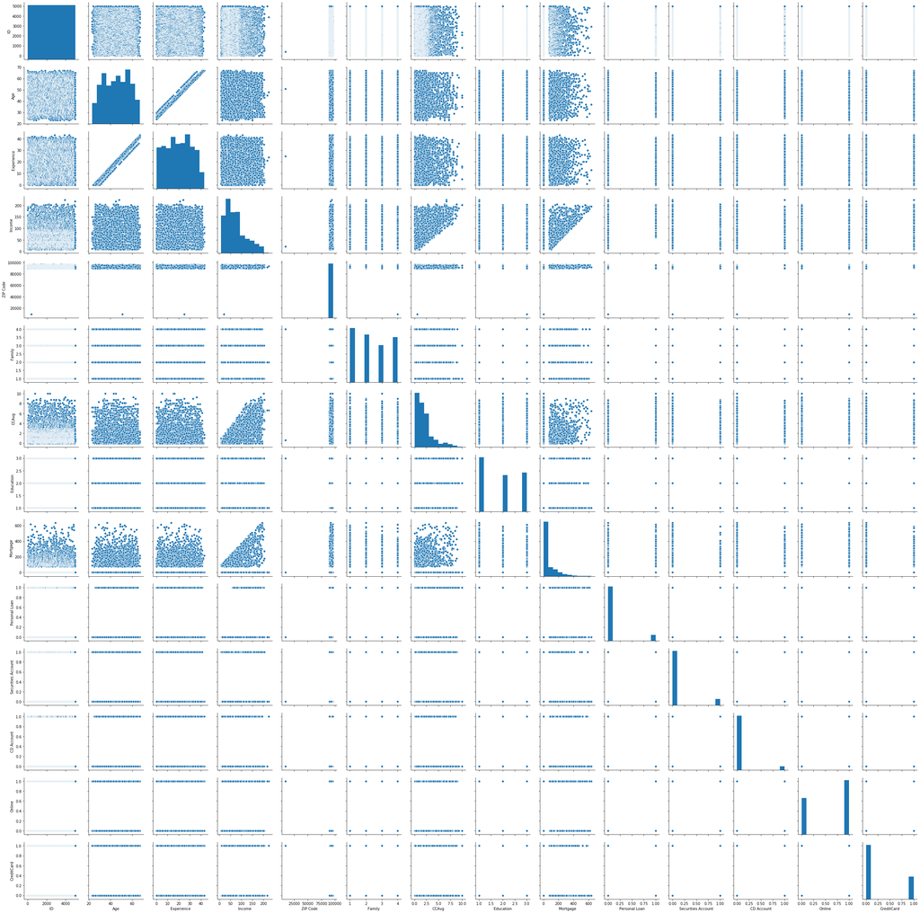

```python
#scatterplot
sns.pairplot(data)
```

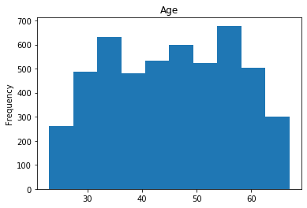

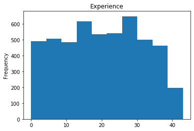

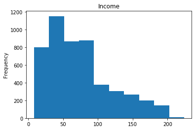

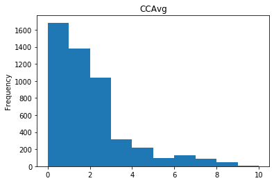

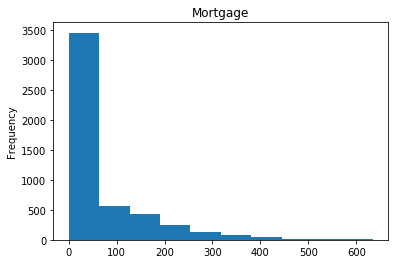

```python
## Age -
data.Age.plot(kind='hist',title="Age")
plt.show()

## Experience
data.Experience.plot(kind='hist',title="Experience")
plt.show()

## Income - Annual income
data.Income.plot(kind='hist',title="Income")
plt.show()

## CCAvg - Average credit card spending
data['CCAvg'].plot(kind='hist',title="CCAvg")
plt.show()

## Mortgage - Value of House Mortgage
data['Mortgage'].plot(kind='hist',title="Mortgage")
plt.show()
```

```python
# Counts for target variable
## Personal loan - Did the customer accept the personal loan offered in the last campaign?
print(data['Personal Loan'].value_counts(dropna = False))
```

```
0    4520
1     480
Name: Personal Loan, dtype: int64
```

Correlation

```python
data.drop(['ID', 'ZIP Code'], axis = 1, inplace = True)
data.columns
```

```
Index(['Age', 'Experience', 'Income', 'Family', 'CCAvg', 'Education',
       'Mortgage', 'Personal Loan', 'Securities Account', 'CD Account',
       'Online', 'CreditCard'],
      dtype='object')
```

[figure not shown]

```python
# Correlation with heat map
corr = data.corr()
sns.set_context("notebook", font_scale=1.0, rc={"lines.linewidth": 2.5})
plt.figure(figsize=(13,7))
# create a mask so we only see the correlation values once
mask = np.zeros_like(corr)
mask[np.triu_indices_from(mask, 1)] = True
a = sns.heatmap(corr,mask=mask, annot=True, fmt='.2f')
rotx = a.set_xticklabels(a.get_xticklabels(), rotation=90)
roty = a.set_yticklabels(a.get_yticklabels(), rotation=30)
```

Income and CCAvg is moderately correlated. Age and Experience is highly correlated

# Describe Cleaned Dataset

```python
# dropping age column
data.drop(['Age', 'Online', 'CreditCard'], axis = 1, inplace = True)
data.columns
```

```
Index(['Experience', 'Income', 'Family', 'CCAvg', 'Education', 'Mortgage',
       'Personal Loan', 'Securities Account', 'CD Account'],
      dtype='object')
```

```python
# Separating dependent and independent variables
X = data.drop(['Personal Loan'], axis = 1)
y = data['Personal Loan']

display(X.describe().T, X.shape, y.shape)
```

[output not shown]

```
(5000, 8)
```

```
(5000,)
```

```python
# Total numbers of rows and columns
data.shape
```

```
(5000, 9)
```

```python
# Descriptive statistics of the cleaned dataset
data.describe().T
```

[output not shown]

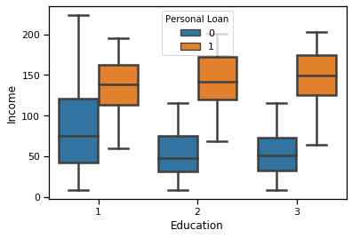

```python
sns.boxplot(x='Education',y='Income',hue='Personal Loan',data=data)
```

Observation: Education level 1 has higher incomes Customers who go for loan have almost same income distribution regardless of education level

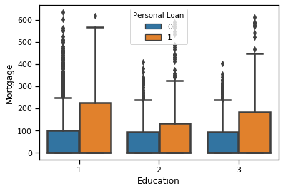

```python
sns.boxplot(x="Education", y="Mortgage", hue="Personal Loan", data=data)
```

Customers having high mortgage and those who dont have taken loan.

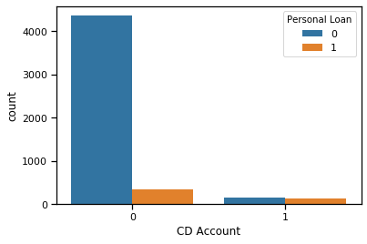

```python
sns.countplot(x='CD Account',data=data,hue='Personal Loan')
```

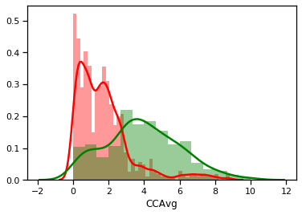

```python
sns.distplot(data[data['Personal Loan'] == 0]['CCAvg'], color = 'r')
sns.distplot(data[data['Personal Loan'] == 1]['CCAvg'], color = 'g')
```

Observation: The graph show persons who have personal loan have a higher credit card average. Average credit card spending with a median of 3800 dollar indicates a higher probability of personal loan. Lower credit card spending with a median of 1400 dollars is less likely to take a loan.

# Applying models

Use different classification models (Logistic, K-NN and Naïve Bayes) to predict the likelihood of a liability customer buying personal loans

```python
# Separating dependent and independent variables
X = data.drop(['Personal Loan'], axis = 1)
y = data['Personal Loan']

display(X.describe().T, X.shape, y.shape)
```

[output not shown]

```
(5000, 8)
```

```
(5000,)
```

# Logistic Regression:

```python
# Splitting the data into training and test set in the ratio of 70:30 respectively
X_train, X_test, y_train, y_test = train_test_split(X, y, test_size = 0.3, random_state = 42)
display(X_train.shape, X_test.shape, y_train.shape, y_test.shape)
```

```
(3500, 8)
```

```
(1500, 8)
```

```
(3500,)
```

```
(1500,)
```

```
Logistic Regression Scores without Hyperparameter Tuning


LR accuracy for train set: 0.947
LR accuracy for test set: 0.945

              precision    recall  f1-score   support

           0       0.96      0.98      0.97      1343
           1       0.82      0.62      0.70       157

    accuracy                           0.95      1500
   macro avg       0.89      0.80      0.84      1500
weighted avg       0.94      0.95      0.94      1500


Confusion Matrix:
 [[1321   22]
 [  60   97]]

Accuracy Score:
 0.945
```

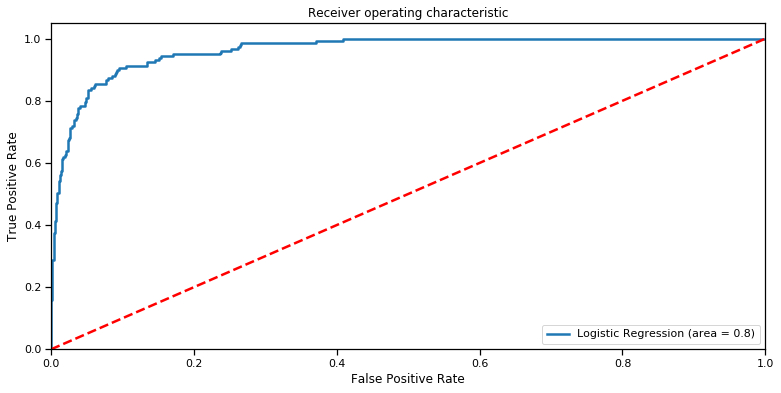

```python
# LR model without hyperparameter tuning
LR = LogisticRegression()
LR.fit(X_train, y_train)

print('Logistic Regression Scores without Hyperparameter Tuning\n\n')
print('LR accuracy for train set: {0:.3f}'.format(LR.score(X_train, y_train)))
print('LR accuracy for test set: {0:.3f}'.format(LR.score(X_test, y_test)))

y_true, y_pred = y_test, LR.predict(X_test)

# Classification Report
print('\n{}'.format(classification_report(y_true, y_pred)))

# Confusion Matrix
cm = confusion_matrix(y_true, y_pred)
print('\nConfusion Matrix:\n', cm)

# Accuracy Score
auc = accuracy_score(y_true, y_pred)
print('\nAccuracy Score:\n', auc.round(3))

# ROC Curve
LR_roc_auc = roc_auc_score(y_true, LR.predict(X_test))
fpr, tpr, thresholds = roc_curve(y_true, LR.predict_proba(X_test)[:,1])
plt.figure(figsize = (12.8 , 6))
plt.plot(fpr, tpr, label = 'Logistic Regression (area = {})'.\
         format(LR_roc_auc.round(2)))
plt.plot([0, 1], [0, 1],'r--')
plt.xlim([0.0, 1.0])
plt.ylim([0.0, 1.05])
plt.xlabel('False Positive Rate')
plt.ylabel('True Positive Rate')
plt.title('Receiver operating characteristic')
plt.legend(loc = 'lower right')
plt.show()
```

```
Logistic Regression Scores with Hyperparameter Tuning


Best Hyper Parameters are:  {'C': 1, 'max_iter': 130, 'penalty': 'l2'}
Best Score is:  0.949
LR accuracy for train set: 0.950
LR accuracy for test set: 0.943

              precision    recall  f1-score   support

           0       0.95      0.98      0.97      1343
           1       0.81      0.60      0.69       157

    accuracy                           0.94      1500
   macro avg       0.88      0.79      0.83      1500
weighted avg       0.94      0.94      0.94      1500


Confusion Matrix:
 [[1321   22]
 [  63   94]]

Accuracy Score:
 0.943
```

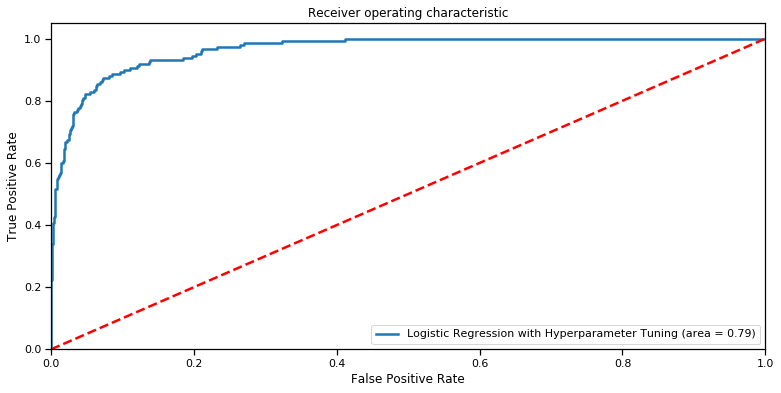

```python
# LR with hyperparameter tuning
LR = LogisticRegression(random_state = 42)

params = {'penalty': ['l1', 'l2'], 'C': [0.001, 0.01, 0.1, 1, 10, 100], 'max_iter': [100, 110, 120, 130, 140]}

skf = StratifiedKFold(n_splits = 10)
LR_hyper = GridSearchCV(LR, param_grid = params, n_jobs = -1, cv = skf)

LR_hyper.fit(X_train, y_train)

print('Logistic Regression Scores with Hyperparameter Tuning\n\n')
print('Best Hyper Parameters are: ', LR_hyper.best_params_)
print('Best Score is: ', LR_hyper.best_score_.round(3))

print('LR accuracy for train set: {0:.3f}'.format(LR_hyper.score(X_train, y_train)))
print('LR accuracy for test set: {0:.3f}'.format(LR_hyper.score(X_test, y_test)))

y_true, y_pred = y_test, LR_hyper.predict(X_test)

# Classification Report
print('\n{}'.format(classification_report(y_true, y_pred)))

# Confusion Matrix
cm = confusion_matrix(y_true, y_pred)
print('\nConfusion Matrix:\n', cm)

# Accuracy Score
auc = accuracy_score(y_true, y_pred)
print('\nAccuracy Score:\n', auc.round(3))

# ROC Curve
LR_hyper_roc_auc = roc_auc_score(y_true, LR_hyper.predict(X_test))
fpr, tpr, thresholds = roc_curve(y_true, LR_hyper.predict_proba(X_test)[:,1])
plt.figure(figsize = (12.8 , 6))
plt.plot(fpr, tpr, label = 'Logistic Regression with Hyperparameter Tuning (area = {})'.\
         format(LR_hyper_roc_auc.round(2)))
plt.plot([0, 1], [0, 1],'r--')
plt.xlim([0.0, 1.0])
plt.ylim([0.0, 1.05])
plt.xlabel('False Positive Rate')
plt.ylabel('True Positive Rate')
plt.title('Receiver operating characteristic')
plt.legend(loc = 'lower right')
plt.show()
```

# KNN

```python
# Splitting the data into training and test set in the ratio of 70:30 respectively
X_train, X_test, y_train, y_test = train_test_split(X, y, test_size = 0.3, random_state = 42)
display(X_train.shape, X_test.shape, y_train.shape, y_test.shape)
```

```
(3500, 8)
```

```
(1500, 8)
```

```
(3500,)
```

```
(1500,)
```

```
k-Nearest Neighbor Classifier Scores without feature scaling


k-NN accuracy for train set: 0.943
k-NN accuracy for test set: 0.906

              precision    recall  f1-score   support

           0       0.93      0.97      0.95      1343
           1       0.59      0.33      0.42       157

    accuracy                           0.91      1500
   macro avg       0.76      0.65      0.69      1500
weighted avg       0.89      0.91      0.89      1500


Confusion Matrix:
 [[1307   36]
 [ 105   52]]

Accuracy Score:
 0.906
```

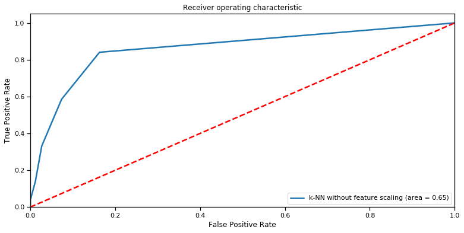

```python
# KNN Model without scaling the features
KNN = KNeighborsClassifier()
KNN.fit(X_train, y_train)

print('k-Nearest Neighbor Classifier Scores without feature scaling\n\n')
print('k-NN accuracy for train set: {0:.3f}'.format(KNN.score(X_train, y_train)))
print('k-NN accuracy for test set: {0:.3f}'.format(KNN.score(X_test, y_test)))

y_true, y_pred = y_test, KNN.predict(X_test)

# Classification Report
print('\n{}'.format(classification_report(y_true, y_pred)))

# Confusion Matrix
cm = confusion_matrix(y_true, y_pred)
print('\nConfusion Matrix:\n', cm)

# Accuracy Score
auc = accuracy_score(y_true, y_pred)
print('\nAccuracy Score:\n', auc.round(3))

# ROC Curve
KNN_roc_auc = roc_auc_score(y_true, KNN.predict(X_test))
fpr, tpr, thresholds = roc_curve(y_true, KNN.predict_proba(X_test)[:,1])
plt.figure(figsize = (12.8 , 6))
plt.plot(fpr, tpr, label = 'k-NN without feature scaling (area = {})'.\
         format(KNN_roc_auc.round(2)))
plt.plot([0, 1], [0, 1],'r--')
plt.xlim([0.0, 1.0])
plt.ylim([0.0, 1.05])
plt.xlabel('False Positive Rate')
plt.ylabel('True Positive Rate')
plt.title('Receiver operating characteristic')
plt.legend(loc = 'lower right')
plt.show()
```

```python
# Scaling the independent variables
Xs = X.apply(zscore)
display(Xs.describe().T, Xs.shape, y.shape)
```

|  | count | mean | std | min | 25% | 50% | 75% | max |
| --- | --- | --- | --- | --- | --- | --- | --- | --- |
| Experience | 5000.0 | -1.693312e-16 | 1.0001 | -2.014911 | -0.881204 | -0.009122 | 0.862960 | 1.996667 |
| Income | 5000.0 | 1.939449e-16 | 1.0001 | -1.428969 | -0.755483 | -0.212348 | 0.526315 | 3.263712 |
| Family | 5000.0 | 7.850609e-16 | 1.0001 | -1.216855 | -1.216855 | -0.345432 | 0.525991 | 1.397414 |
| CCAvg | 5000.0 | -2.078338e-17 | 1.0001 | -1.108987 | -0.708412 | -0.250611 | 0.321641 | 4.613525 |
| Education | 5000.0 | -6.315837e-16 | 1.0001 | -1.049078 | -1.049078 | 0.141703 | 1.332484 | 1.332484 |
| Mortgage | 5000.0 | 2.810197e-16 | 1.0001 | -0.555524 | -0.555524 | -0.555524 | 0.437558 | 5.688108 |
| Securities Account | 5000.0 | 5.092149e-16 | 1.0001 | -0.341423 | -0.341423 | -0.341423 | -0.341423 | 2.928915 |
| CD Account | 5000.0 | 4.426903e-16 | 1.0001 | -0.253540 | -0.253540 | -0.253540 | -0.253540 | 3.944146 |

```
(5000, 8)
```

```
(5000,)
```

```python
#Splitting the data into training and test set in the ratio of 70:30 respectively
X_train, X_test, y_train, y_test = train_test_split(X, y, test_size = 0.3, random_state = 42)
display(X_train.shape, X_test.shape, y_train.shape, y_test.shape)
```

```
(3500, 8)
```

```
(1500, 8)
```

```
(3500,)
```

```
(1500,)
```

```
k-Nearest Neighbor Classifier Scores after Scaling without Hyperparameter Tuning


k-NN accuracy for train set: 0.943
k-NN accuracy for test set: 0.906

              precision    recall  f1-score   support

           0       0.93      0.97      0.95      1343
           1       0.59      0.33      0.42       157

    accuracy                           0.91      1500
   macro avg       0.76      0.65      0.69      1500
weighted avg       0.89      0.91      0.89      1500


Confusion Matrix:
 [[1307   36]
 [ 105   52]]

Accuracy Score:
 0.906
```

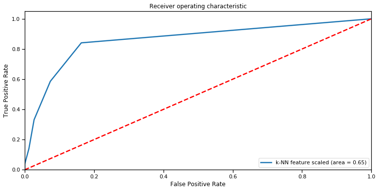

```python
# KNN Model after scaling the features without hyperparameter tuning
KNN = KNeighborsClassifier()
KNN.fit(X_train, y_train)

print('k-Nearest Neighbor Classifier Scores after Scaling without Hyperparameter Tuning\n\n')
print('k-NN accuracy for train set: {0:.3f}'.format(KNN.score(X_train, y_train)))
print('k-NN accuracy for test set: {0:.3f}'.format(KNN.score(X_test, y_test)))

y_true, y_pred = y_test, KNN.predict(X_test)

# Classification Report
print('\n{}'.format(classification_report(y_true, y_pred)))

# Confusion Matrix
cm = confusion_matrix(y_true, y_pred)
print('\nConfusion Matrix:\n', cm)

# Accuracy Score
auc = accuracy_score(y_true, y_pred)
print('\nAccuracy Score:\n', auc.round(3))

# ROC Curve
KNN_roc_auc = roc_auc_score(y_true, KNN.predict(X_test))
fpr, tpr, thresholds = roc_curve(y_true, KNN.predict_proba(X_test)[:,1])
plt.figure(figsize = (12.8 , 6))
plt.plot(fpr, tpr, label = 'k-NN feature scaled (area = {})'.\
         format(KNN_roc_auc.round(2)))
plt.plot([0, 1], [0, 1],'r--')
plt.xlim([0.0, 1.0])
plt.ylim([0.0, 1.05])
plt.xlabel('False Positive Rate')
plt.ylabel('True Positive Rate')
plt.title('Receiver operating characteristic')
plt.legend(loc = 'lower right')
plt.show()
```

```
k-Nearest Neighbor Classifier Scores after Hyperparameter Tuning


Best Hyper Parameters are:  {'algorithm': 'auto', 'n_neighbors': 17, 'weights': 'distance'}

Best Score is:  0.915
k-NN accuracy for train set: 1.000
k-NN accuracy for test set: 0.911

              precision    recall  f1-score   support

           0       0.92      0.98      0.95      1343
           1       0.67      0.29      0.40       157

    accuracy                           0.91      1500
   macro avg       0.80      0.64      0.68      1500
weighted avg       0.90      0.91      0.89      1500


Confusion Matrix:
 [[1321   22]
 [ 112   45]]

Accuracy Score:
 0.911
```

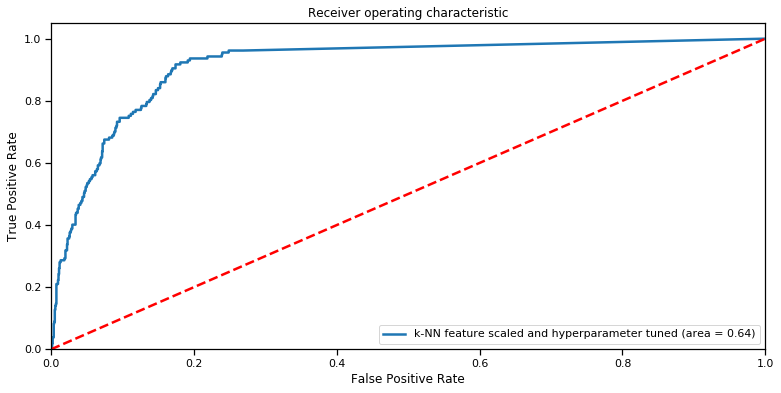

```python
# KNN with hyperparameter tuning
KNN = KNeighborsClassifier(n_jobs = -1)

params = {'n_neighbors': list(range(1, 40, 2)), 'weights': ['uniform', 'distance'],
          'algorithm': ['auto', 'ball_tree', 'kd_tree', 'brute']}

skf = StratifiedKFold(n_splits = 10, random_state = 42)
KNN_hyper = GridSearchCV(KNN, param_grid = params, n_jobs = -1, cv = skf)

KNN_hyper.fit(X_train, y_train)

print('k-Nearest Neighbor Classifier Scores after Hyperparameter Tuning\n\n')
print('Best Hyper Parameters are: ', KNN_hyper.best_params_)
print('\nBest Score is: ', KNN_hyper.best_score_.round(3))

print('k-NN accuracy for train set: {0:.3f}'.format(KNN_hyper.score(X_train, y_train)))
print('k-NN accuracy for test set: {0:.3f}'.format(KNN_hyper.score(X_test, y_test)))

y_true, y_pred = y_test, KNN_hyper.predict(X_test)

# Classification Report
print('\n{}'.format(classification_report(y_true, y_pred)))

# Confusion Matrix
cm = confusion_matrix(y_true, y_pred)
print('\nConfusion Matrix:\n', cm)

# Accuracy Score
auc = accuracy_score(y_true, y_pred)
print('\nAccuracy Score:\n', auc.round(3))

# ROC Curve
KNN_hyper_roc_auc = roc_auc_score(y_true, KNN_hyper.predict(X_test))
fpr, tpr, thresholds = roc_curve(y_true, KNN_hyper.predict_proba(X_test)[:,1])
plt.figure(figsize = (12.8 , 6))
plt.plot(fpr, tpr, label = 'k-NN feature scaled and hyperparameter tuned (area = {})'.\
         format(KNN_hyper_roc_auc.round(2)))
plt.plot([0, 1], [0, 1],'r--')
plt.xlim([0.0, 1.0])
plt.ylim([0.0, 1.05])
plt.xlabel('False Positive Rate')
plt.ylabel('True Positive Rate')
plt.title('Receiver operating characteristic')
plt.legend(loc = 'lower right')
plt.show()
```

# Naive Bayes classifier

```
Naive Bayes Classifier Scores


NB accuracy for train set: 0.882
NB accuracy for test set: 0.892

              precision    recall  f1-score   support

           0       0.95      0.93      0.94      1343
           1       0.49      0.60      0.54       157

    accuracy                           0.89      1500
   macro avg       0.72      0.76      0.74      1500
weighted avg       0.90      0.89      0.90      1500


Confusion Matrix:
 [[1244   99]
 [  63   94]]

Accuracy Score:
 0.892
```

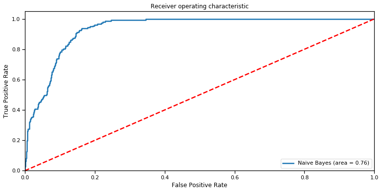

```python
# Naive Bayes Model
NB = GaussianNB()
NB.fit(X_train, y_train)

print('Naive Bayes Classifier Scores\n\n')
print('NB accuracy for train set: {0:.3f}'.format(NB.score(X_train, y_train)))
print('NB accuracy for test set: {0:.3f}'.format(NB.score(X_test, y_test)))

y_true, y_pred = y_test, NB.predict(X_test)

# Classification Report
print('\n{}'.format(classification_report(y_true, y_pred)))

# Confusion Matrix
cm = confusion_matrix(y_true, y_pred)
print('\nConfusion Matrix:\n', cm)

# Accuracy Score
auc = accuracy_score(y_true, y_pred)
print('\nAccuracy Score:\n', auc.round(3))

# ROC Curve
NB_roc_auc = roc_auc_score(y_true, NB.predict(X_test))
fpr, tpr, thresholds = roc_curve(y_true, NB.predict_proba(X_test)[:,1])
plt.figure(figsize = (12.8 , 6))
plt.plot(fpr, tpr, label = 'Naive Bayes (area = {})'.\
         format(NB_roc_auc.round(2)))
plt.plot([0, 1], [0, 1],'r--')
plt.xlim([0.0, 1.0])
plt.ylim([0.0, 1.05])
plt.xlabel('False Positive Rate')
plt.ylabel('True Positive Rate')
plt.title('Receiver operating characteristic')
plt.legend(loc = 'lower right')
plt.show()
```

# Decision Tree:

```python
dTree = DecisionTreeClassifier(criterion = 'gini', random_state=1)
dTree.fit(X_train, y_train)
```

```
DecisionTreeClassifier(ccp_alpha=0.0, class_weight=None, criterion='gini',
                       max_depth=None, max_features=None, max_leaf_nodes=None,
                       min_impurity_decrease=0.0, min_impurity_split=None,
                       min_samples_leaf=1, min_samples_split=2,
                       min_weight_fraction_leaf=0.0, presort='deprecated',
                       random_state=1, splitter='best')
```

```python
print(dTree.score(X_train, y_train))
print(dTree.score(X_test, y_test))
```

```
1.0
0.9793333333333333
```

```python
dTreeR = DecisionTreeClassifier(criterion = 'gini', max_depth = 3, random_state=1)
dTreeR.fit(X_train, y_train)
print(dTreeR.score(X_train, y_train))
print(dTreeR.score(X_test, y_test))
```

```
0.9831428571428571
0.984
```

```python
# importance of features in the tree building ( The importance of a feature is computed as the
#(normalized) total reduction of the criterion brought by that feature. It is also known as the Gini importance )

print (pd.DataFrame(dTreeR.feature_importances_, columns = ["Imp"], index = X_train.columns))
```

```
                         Imp
Experience          0.000000
Income              0.341657
Family              0.173470
CCAvg               0.036714
Education           0.431295
Mortgage            0.000000
Securities Account  0.000000
CD Account          0.016864
```

```
0.984
```

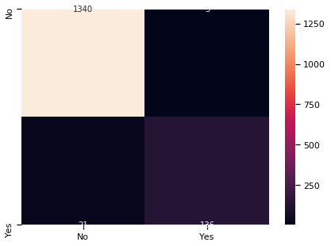

```python
print(dTreeR.score(X_test , y_test))
y_predict = dTreeR.predict(X_test)

cm=metrics.confusion_matrix(y_test, y_predict, labels=[0, 1])

df_cm = pd.DataFrame(cm, index = [i for i in ["No","Yes"]],
                  columns = [i for i in ["No","Yes"]])
plt.figure(figsize = (7,5))
sns.heatmap(df_cm, annot=True ,fmt='g')
```

# Model Comparison:

```python
skfold = StratifiedKFold(n_splits=5)
```

```python
result_LR = cross_val_score(LogisticRegression(solver='lbfgs'),X,y,cv=skfold)
print("Accuracy of Logistic Regression model: %.2f%% (std: %.2f%%)" % (result_LR.mean()*100.0,result_LR.std()*100))
result_KNN = cross_val_score(KNeighborsClassifier(n_neighbors=7),X_train,y_train,cv=skfold)
print("Accuracy of KNN model: %.2f%% (std: %.2f%%)" % (result_KNN.mean()*100.0,result_KNN.std()*100))
result_GNB = cross_val_score(GaussianNB(),X,y,cv=skfold)
print("Accuracy of Naive Bayes: %.2f%% (std: %.2f%%)" % (result_GNB.mean()*100.0,result_GNB.std()*100))
result_DT = cross_val_score(DecisionTreeClassifier(criterion = 'gini', random_state=1),X,y,cv=skfold)
print("Accuracy of Decision Tree: %.2f%% (std: %.2f%%)" % (result_DT.mean()*100.0,result_DT.std()*100))
result = [result_LR,result_KNN,result_GNB,result_DT]
```

```
Accuracy of Logistic Regression model: 94.54% (std: 0.57%)
Accuracy of KNN model: 90.94% (std: 1.01%)
Accuracy of Naive Bayes: 88.38% (std: 0.55%)
Accuracy of Decision Tree: 98.34% (std: 0.23%)
```

# Conclusion:

Conclusion and understanding of models results The aim of Thera Bank is to convert their Liability customers into Loan Customers. Classification algorithms (Logistic Regression, KNN and Naive Bayes) were used in this study. From data analysis, it can be seen that 'Decision Tree' has the highest score and accuracy (98.34%) and it can be chosen as the best model for this case study.